# o-well-2

Sean Wallace [sean.d.wallace]

#Includes

```r
library(ggplot2)
which.github = "local";
github.local = "C:/_git_/WSU_STATS419_2021/"
github.remote = "https://raw.githubusercontent.com/swallace-wsu/WSU_STATS419_2021/main/";
saudiDataPath = "datasets/oWellData/saudi.csv";


# Current workspace is local, include function-owell
include.me = paste0( github.local, "functions/functions-owell.R" );
source(include.me);
```

#Load Data

```r
# Load dataset and read in, save in RDS format
saudiData = paste0(github.local, "datasets/oWellData/saudi.csv")
owell.saudi = read.csv(saudiData, TRUE);


#Make a list of the two dataframes, then save to RDS format
wells <- list(saudi=NULL);
wells$saudi <- list(combined=owell.saudi)
saveRDS(wells, "combinedData.rds");

#view created dataframe structure
print("Dataframe headers:")
print(head(owell.saudi))
writeLines("\n")
print("Dataframe column names")
colnames(owell.saudi)
writeLines("\n")
print("Dataframe number of columns")
ncol(owell.saudi)
writeLines("\n")
print("Dataframe number of rows")
nrow(owell.saudi)
writeLines("\n")
```

##Merging two dataframes Instead of manually merging the chemical and metals dataset like I did, I could have instead merged them in R

```r
#Example for merging a new column into an existing dataframe
#The two frames must have the same number of subjects
#If I wanted to add the "temp" column from an existing "aveTemp" dataframe to #my owell.saudi dataframe:


#owell.saudimodified <- owell.saudi
#owell.saudimodified$temp <- aveTemp$temp
```

#Inquiries (Logical indexing) Create logical indexing rules for manipulating the dataframes, the results can be used to graph the pertinent data and conclude whether the datapoints have any meaningful relations.

In the future this should be split out into it’s create_sub_index function. ##Sub-Index Altitude >1000ft

```r
#Seperate all wells where the altitude is >500ft
#Create a logical vector
altitude_over_1000 <- owell.saudi$altitude > 1000
#View logical vector
head(altitude_over_1000)
#Take all entries from dataset where "altitude_over_500" is true
owell.saudi[altitude_over_1000,]
#return which rows satisfy the logical criteria
which_altitude_over_1000 <- which(altitude_over_1000)
which_altitude_over_1000
```

##Sub-Index PH < 7.5

```r
#Seperate all wells where the ph < 7.5
#Create a logical vector
ph_under_7p5 <- owell.saudi$pH < 7.5
#View logical vector
head(ph_under_7p5)
#Take all entries from dataset where "altitude_over_500" is true
owell.saudi[ph_under_7p5,]
#return which rows satisfy the logical criteria
which_ph_under_7p5 <- which(ph_under_7p5)
which_ph_under_7p5
```

##Complex Sub-Index Altitude > 1000 & PH < 7.5 Combination of the two logical indexes to create a complex sub-index In this case results are alt>1000 ph<7.5 using the previosult created logical rules created above.

```r
#Seperate all wells where the ph < 7.5
#Create a logical vector
alt_over_1000_ph_under_7p5 <- altitude_over_1000 & ph_under_7p5
#View logical vector
head(alt_over_1000_ph_under_7p5)
#Take all entries from dataset where "altitude_over_500" is true
owell.saudi[alt_over_1000_ph_under_7p5,]
#return which rows satisfy the logical criteria
which_alt_over_1000_ph_under_7p5 <- which(alt_over_1000_ph_under_7p5)
which_alt_over_1000_ph_under_7p5
```

##Getting a summary The summary command will give a list of values from the dataframe, including min,median,mean,and max. Additionally, the command will allow you to verify there is no missing information.

If there is missing information the statistical results will come back as NA. If there is missing data the “is.na” function can be used to create a logical index containing all rows where the data is present, for example:

not_missing <- !is.na(owell.saudi$ph)

would return all rows where there is a valid entry for the ph column.

This is useful for a high level review of the dataframe.

```r
summary(owell.saudi)
```

##Getting Column Data Types R will automatically assign a suitable data type to the columns when it reads in the csv and creates the dataframe. Use this command to verify they are correct.

```r
str(owell.saudi)
```

##Performing Fisher Exact test Getting the p-value for two categories

```r
fisher.test(table(owell.saudi$altitude, owell.saudi$pH))
```

##Get mean altitude values for datapoints with a certain pH using the tapply function, can also do for min, max, and median

```r
tapply(owell.saudi$altitude, owell.saudi$pH, mean)
```

##Random Data Graphing (Scatter Plot)

```r
#XY plot using 100 random datapoints
#X-axis mean of 0 within 1 standard deviation
#Y-axis mean of 10 within 2 standard deviations
x = rnorm((n=100), mean = 0, sd=1);
y = rnorm(n, mean = 10, sd = 2);
plot(x,y,asp=1);
```

[output not shown]

##Owell Data Altitude for each Row

```r
plot(owell.saudi$altitude)
```

[output not shown]

##Owell Data Altitude v pH

```r
plot(owell.saudi$altitude, owell.saudi$pH)
```

[output not shown]

##Owell Data geology v pH

```r
plot(factor(owell.saudi$geology), owell.saudi$pH)
```

[output not shown]

##Owell Data geology v ph table When using factors as the x-axis this could be useful for verifying the categories that are used.

```r
table(factor(owell.saudi$geology), owell.saudi$pH)
```

##GGplot2 Altitude v pH

```r
ggplot(owell.saudi, aes(y=pH, x=altitude)) + geom_point()
```

[output not shown]

##GGplot2 Altitude v pH (w Colors) Point colors are based on the NO3 value

```r
ggplot(owell.saudi, aes(y=pH, x=altitude, color=NO3)) + geom_point()
```

[output not shown]

##GGplot2 Altitude v pH (w/ Colors and size) Colors based on NO3 value and size of point based on Eh

```r
ggplot(owell.saudi, aes(y=pH, x=altitude, size=Eh, color=NO3)) +   geom_point()
```

[output not shown]

##GGplot2 ph v geology box plot Need to figure out how to rotate the x-axis labels to a vertical position

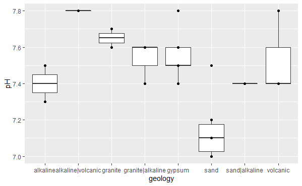

```r
ggplot(owell.saudi, aes(x=geology, y=pH))+geom_boxplot() + geom_point()
```